# Calculating a simple regression by hand

Leandro Ledesma

2024-02-07

### Our data

We will be using the following data from the Data Sets of the ‘Statistical Methods for Psychology by David C. Howell’ website. This data set contains the variables Height, Weight and Sex. We will be calculating by hand the regression equation between Height and Weight while ignoring Sex.

### Universal block code settings

```r
knitr::opts_chunk$set(echo = TRUE)
knitr::opts_chunk$set(comment = NULL)
knitr::opts_chunk$set(message = FALSE)
```

### Load in the data manipulation packages

```r
library(tidyverse)
library(ggplot2)
library(kableExtra)
```

### Load in the data

```r
# Load in the data
data <- read.delim("https://www.uvm.edu/~statdhtx/methods8/DataFiles/Ex9-31.dat")

# Explore the data
dim(data)
```

```
[1] 57  3
```

```r
str(data)
```

```
'data.frame':   57 obs. of  3 variables:
 $ Sex   : int  1 1 1 1 1 1 1 1 1 1 ...
 $ Height: num  70 67 72 75 68 69 71.5 71 72 69 ...
 $ Weight: int  150 140 180 190 145 150 164 140 142 136 ...
```

### Plot the data

From plotting the data below and including the regression line, we can see whether Height and Weight are positively or negatively related to each other. Additionally, we can use the regression line to predict the Weight of someone based on the values of their height.

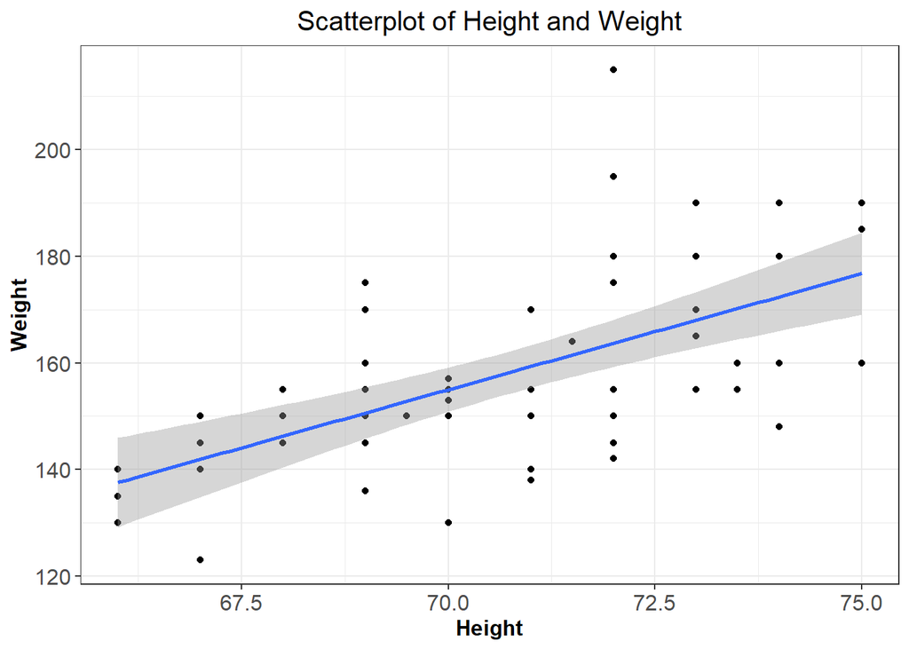

```r
# Create a scatterplot
data %>%
  ggplot(aes(x = Height, y = Weight)) +
  geom_point() +
  geom_smooth(method = "lm") +
  theme_bw() +
  labs(title = "Scatterplot of Height and Weight",
       x = "Height",
       y = "Weight") +
  theme(plot.title = element_text(size = 15,
                                  hjust = 0.5),
        axis.title = element_text(size = 12, face = "bold"),
        axis.text = element_text(size = 12))
```

### Calculating a regression line

The regression line equation is pretty straightforward. We take the values of our predictor variable ($X$) and then have to transform it with some weight ($b$) then add a constant to it ($a$) then that will give you a predicted value of the outcome variable. The equation is as follows:

$$\begin{align*}
\hat{Y} = bX + a
\end{align*}$$

However before we can use the equation from above to calculate our predicted values, we need to first calculate or regression coefficient ($b$)and y-intercept ($a$). The equations to calculate them are below and the code will focus on this aspect first.

$$\begin{align*}
a = \overline{Y} - b\overline{X}
\end{align*}$$

$$\begin{align*}
b = \frac {cov_{XY}} {s_{x}^2}
\end{align*}$$

### Calculating the regression coefficient (b)

We first need to calculate the regression coefficient since our y-intercept depends on this value. To calculate the regression coefficient, we need to take the covariance of X and Y then divide that by the variance of X. Let’s do that below. However, keep in mind this is sample data, so we will be using the sample covariance, which has N-1 for the degrees of freedom.

$$\begin{align*}
cov_{XY} = \frac {\Sigma(X - \overline{X})(Y - \overline{Y})} {N - 1}
\end{align*}$$

Additionally the variance also needs to be calculate and will function as the denominator for the output of the covariance. The variance we care for is the predictor variable ($X$).

$$\begin{align*}
s_{X}^2 = \frac{ \Sigma(X - \overline{X})^2} {N - 1}
\end{align*}$$

When we are dividing the covariance of both X and Y by the variance of X, what we are really getting is an output that represents the amount of variance in Y that is explained by X (I think). Let’s use these two fomulas (covariance of X and Y and the variance of X) to calculate our regression coefficient.

```r
# Calculating the covariance
data.cov <- data %>%
  rename(x = Height,
         y = Weight) %>%
  mutate(mean.x = mean(x),
         mean.y = mean(y),
         deviations.x = x - mean.x,
         deviations.y = y - mean.y,
         multp.xy = deviations.x * deviations.y,
         sum = sum(multp.xy),
         df = nrow(data) -1,
         cov.xy = sum/df) %>%
  round(3)

# Print the covariance
data.cov %>%
  head() %>%
  kbl() %>%
  kable_styling()
```

| Sex | x | y | mean.x | mean.y | deviations.x | deviations.y | multp.xy | sum | df | cov.xy |
| --- | --- | --- | --- | --- | --- | --- | --- | --- | --- | --- |
| 1 | 70 | 150 | 70.754 | 158.263 | -0.754 | -8.263 | 6.234 | 1627.184 | 56 | 29.057 |
| 1 | 67 | 140 | 70.754 | 158.263 | -3.754 | -18.263 | 68.567 | 1627.184 | 56 | 29.057 |
| 1 | 72 | 180 | 70.754 | 158.263 | 1.246 | 21.737 | 27.076 | 1627.184 | 56 | 29.057 |
| 1 | 75 | 190 | 70.754 | 158.263 | 4.246 | 31.737 | 134.742 | 1627.184 | 56 | 29.057 |
| 1 | 68 | 145 | 70.754 | 158.263 | -2.754 | -13.263 | 36.532 | 1627.184 | 56 | 29.057 |
| 1 | 69 | 150 | 70.754 | 158.263 | -1.754 | -8.263 | 14.497 | 1627.184 | 56 | 29.057 |

```r
# Calculate the variance of x
x.var <- data %>%
  rename(x = Height,
         y = Weight) %>%
  mutate(mean.x = mean(x),
         deviations.x = x - mean.x,
         `deviations.x^2` = deviations.x^2,
         SS = sum(`deviations.x^2`),
         df = nrow(data)-1,
         variance.x = SS/df) %>%
  round(3)


# Print the variance of x
x.var %>%
  head() %>%
  kbl() %>%
  kable_styling()
```

| Sex | x | y | mean.x | deviations.x | deviations.x^2 | SS | df | variance.x |
| --- | --- | --- | --- | --- | --- | --- | --- | --- |
| 1 | 70 | 150 | 70.754 | -0.754 | 0.569 | 373.561 | 56 | 6.671 |
| 1 | 67 | 140 | 70.754 | -3.754 | 14.095 | 373.561 | 56 | 6.671 |
| 1 | 72 | 180 | 70.754 | 1.246 | 1.552 | 373.561 | 56 | 6.671 |
| 1 | 75 | 190 | 70.754 | 4.246 | 18.025 | 373.561 | 56 | 6.671 |
| 1 | 68 | 145 | 70.754 | -2.754 | 7.587 | 373.561 | 56 | 6.671 |
| 1 | 69 | 150 | 70.754 | -1.754 | 3.078 | 373.561 | 56 | 6.671 |

```r
# Calculate the regression coefficient
b = unique(data.cov$cov.xy)/unique(x.var$variance.x)

# Print the regression coefficient
round(b,2)
```

```
[1] 4.36
```

### Calculating the y-intercept (a)

This calculation is much easier than the former. We will use the regression coefficient ($b$) and the means of our predictor and outcome variable to calculate $a$.

```r
# Calculating the y-intercept
data.means <- data %>%
  rename(x = Height,
         y = Weight) %>%
  mutate(mean.x = mean(x),
         mean.y = mean(y)) %>%
  round(3)


# Calculate the y-intercept
a = unique(data.means$mean.y - (b * data.means$mean.x))

# Print the y-intercept
round(a,2)
```

```
[1] -149.92
```

### Using the regression to predict Y values

Now that we have $b$ and $a$ calculated, we can use them for every value of x to predict the respective $\hat{Y}$.

```r
# Calculating our fitted/predicted values
data.fitted <- data %>%
  rename(x = Height,
         y = Weight) %>%
  mutate(y.hat = b*x + a) %>%
  round(3)


# Print the predicted values data frame (Show the first 10)
data.fitted %>%
  head(.,10) %>%
  kbl() %>%
  kable_styling()
```

| Sex | x | y | y.hat |
| --- | --- | --- | --- |
| 1 | 70.0 | 150 | 154.979 |
| 1 | 67.0 | 140 | 141.912 |
| 1 | 72.0 | 180 | 163.690 |
| 1 | 75.0 | 190 | 176.757 |
| 1 | 68.0 | 145 | 146.267 |
| 1 | 69.0 | 150 | 150.623 |
| 1 | 71.5 | 164 | 161.512 |
| 1 | 71.0 | 140 | 159.335 |
| 1 | 72.0 | 142 | 163.690 |
| 1 | 69.0 | 136 | 150.623 |

### How good is our model?

Now the next question we may have is understanding if our model, aka the values that we predicted are accurate or not. We can see in some cases they seem pretty accurate but in others they are not. However, determining this by visual inspection is difficult and kind of tedious. A better way is to use a mathematical approach that informs us how much of the variance of our outcome variable was explained by our predictor variable. To do this we will need to introduce the concept of different types of sum of squares.

### Residual Sum of Squares

```r
# Let's work of our previous data set
SS.residual <- data.fitted %>%
  mutate(residuals = y - y.hat,
         `residuals^2` = residuals^2,
         SS.residual = sum(`residuals^2`))


# Print the SS.residual
SS.R <- unique(SS.residual$SS.residual)

SS.R
```

```
[1] 12361.36
```